# Gradient Analytics Assignment

Jack Wychor

November 25, 2020

# Gradient Metrics Homework Solution

#### Author: Jack Wychor

The following packages were used for this solution:

```r
library(tidyverse)
library(MASS)
library(caret)
library(haven)
library(purrr)
library(reshape2)
library(scales)
library(ordinal)
library(lattice)

select <- dplyr::select
setwd("C:\\Users\\jwych\\Documents\\GitHub\\Gradient_Analytics_HW")
```

## Task 1

##### Find out how each attribute (and level) influences the overall likeliness to download (experiment_data$answer).

**BACKGROUND**: 892 participants were asked to rate "How likely are you to download this mobile app?" for 12 random permutations of a message describing the app.

The first step to completing this task involves loading the data and exploring the distributions and types of data that we will be working with.

```r
experiment_data <-
  read_sav('data/experiment_data.sav')

str(experiment_data)
```

```
tibble [10,704 x 9] (S3: tbl_df/tbl/data.frame)
 $ response_id : chr [1:10704] "R_00zxXbZGxe0owBX" "R_00zxXbZGxe0owBX" "R_00zxXbZGxe0owBX" "R_00zxXbZGxe0owBX" ...
  ..- attr(*, "format.spss")= chr "A17"
 $ task        : num [1:10704] 1 10 11 12 2 3 4 5 6 7 ...
  ..- attr(*, "format.spss")= chr "F8.0"
 $ duration    : chr [1:10704] "3 months" "6 months" "12 months" "3 months" ...
  ..- attr(*, "format.spss")= chr "A9"
 $ offer       : chr [1:10704] "help you lead a better life" "help you lead a better life" "improve your sleep sustainably" "improve your sleep sustainably" ...
  ..- attr(*, "format.spss")= chr "A52"
 $ outcome     : chr [1:10704] "changing your sleep mindset" "changing your sleep mindset" "breaking bad habits and creating new routines" "breaking bad habits and creating new routines" ...
  ..- attr(*, "format.spss")= chr "A45"
 $ price       : chr [1:10704] "$30/month" "$40/month" "$40/month" "$40/month" ...
  ..- attr(*, "format.spss")= chr "A9"
 $ rtb         : chr [1:10704] "cognitive behavioral therapy" "daily text messages from a coach" "cognitive behavioral therapy" "a program created just for you" ...
  ..- attr(*, "format.spss")= chr "A50"
 $ social_proof: chr [1:10704] "leading researchers" "a method that has helped thousands" "a method that has helped thousands" "professional athletes" ...
  ..- attr(*, "format.spss")= chr "A34"
 $ answer      : num [1:10704] 3 4 3 1 2 4 2 3 4 3 ...
  ..- attr(*, "format.spss")= chr "F8.0"
```

### Distributions of Variables

Let's look at the distribution of data for each level of each variable except 'response_id'.

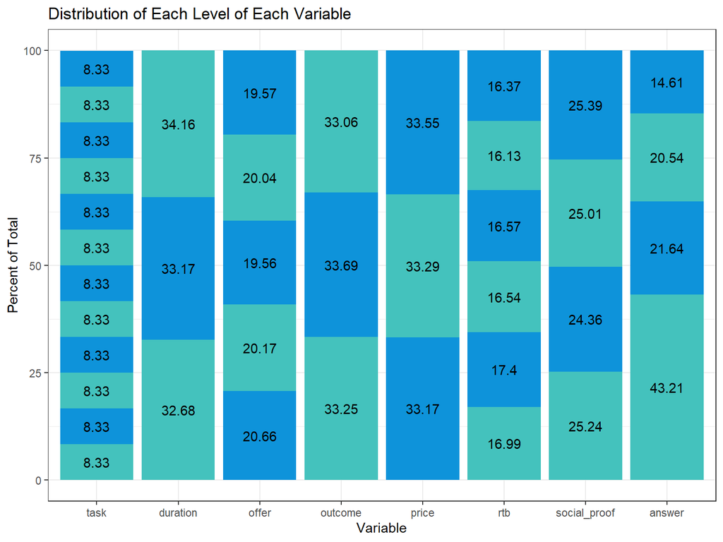

```r
# Melting data by
experiment_data %>%
  melt(id = c("response_id")) %>%
  group_by(value) %>%
  count(variable) %>%
  ungroup() %>% group_by(variable) %>%
  mutate(pct = round(n/sum(n),4) * 100)%>%
  arrange(variable) %>%
  ggplot(aes(x = variable, y = pct, fill = fct_rev(value))) +
  geom_bar(fill = rep(c("#44C2BD", "#0E93DA"),20), stat = "identity", position = position_stack(vjust = 0.5)) +
  geom_text(aes(label = pct), position = position_stack(vjust = 0.5)) +
  theme(legend.position = "none") +
  labs(x = "Variable", y = "Percent of Total", title = "Distribution of Each Level of Each Variable") +
  theme_bw()
```

**NOTE**: Variable names are long and therefore were left out of the visualization. Each colored portion represents the percentage that a level of a variable takes up relative to the total responses for each level of that variable.

Each of variable is currently coded as either numeric or character. Going forward, we need to convert them to factors.

```r
experiment_data <- experiment_data %>%
  mutate_all(~ as.factor(.))
```

With the exception of the dependent variable, 'answer', each variable has an even split of data for each of it's levels. Let's investigate the distribution of responses for 'answer'.

```r
# Percentage of responses for each answer
experiment_data %>%
  select(answer) %>%
  table() %>%
  prop.table() %>%
  round(2) * 100
```

```
.
 1  2  3  4
43 22 21 15
```

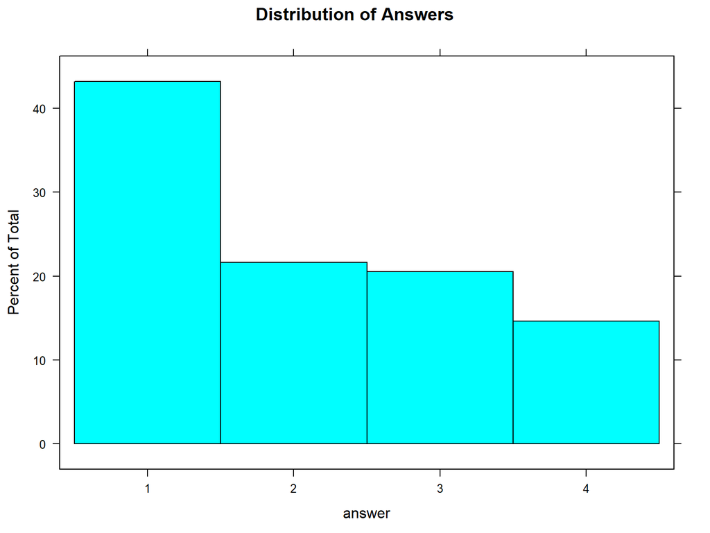

```r
experiment_data %>%
  histogram(~ answer,
             main = "Distribution of Answers",
             data = .)
```

Participants answered 1 (very unlikely) as often as 2 and 3 (somewhate unlikely and somewhat likely, respectively) combined. The target answer, 4 (very likely) was answered the least with only 15% of responses. This imbalance is important to keep in mind although statistically it should not create any problems.

It is important to note that all variables are either ordinal or nominal and will be converted to factors when models are fit.

### Response Distributions for each Predictor

To get a feel for how each level of each predictor may affect participants' likelieness to use the app, bivariate histograms of each relationship were plotted below.

#### Price

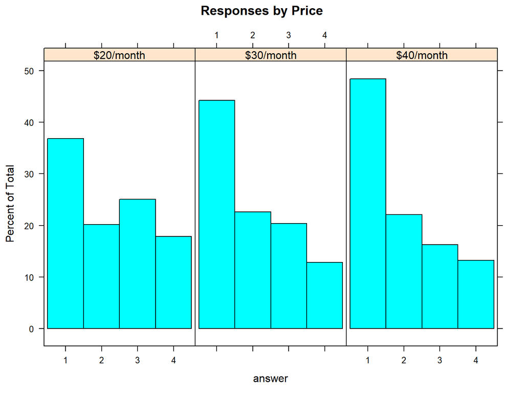

```r
experiment_data %>%
  histogram(~ answer | price,
            main = "Responses by Price",
            data = .)
```

It appears that '$20/month' is the most desirable choice with both the lowest number of 1's and the highest number of 4's.

#### Duration

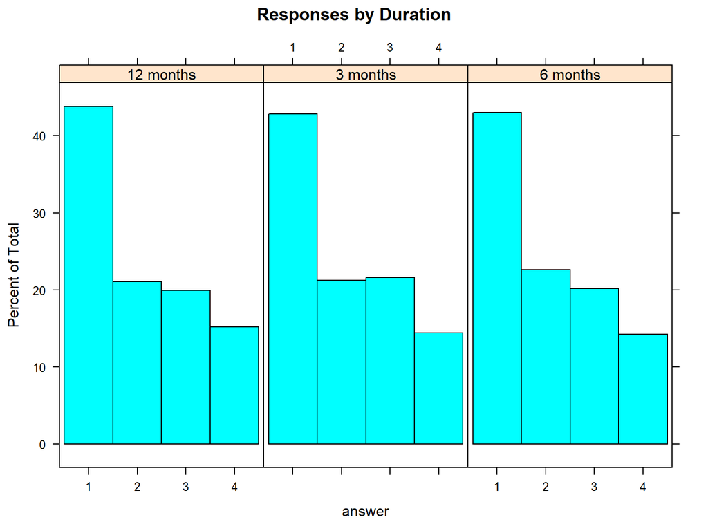

```r
experiment_data %>%
  histogram(~ answer | duration,
            main = "Responses by Duration",
            data = .)
```

Duration looks a little less clear although '3 months' has a slight edge in terms of the number of 3s compared to '6 months'.

#### Offer

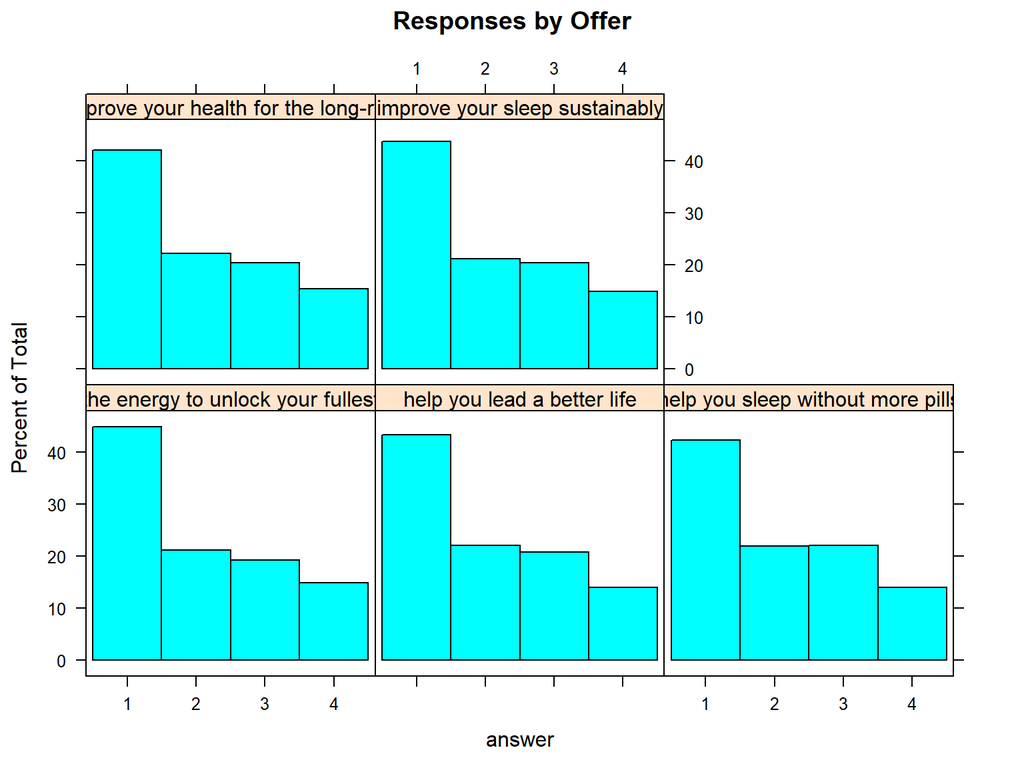

```r
experiment_data %>%
  histogram(~ answer | offer,
            main = "Responses by Offer",
            data = .)
```

Similar to 'duration', responses tend to match the answers distribution. At a glance, the 'help you sleep more without pills' looks the best with a slightly lower rate of 1s and slightly higher rate of 3s than average.

#### Outcome

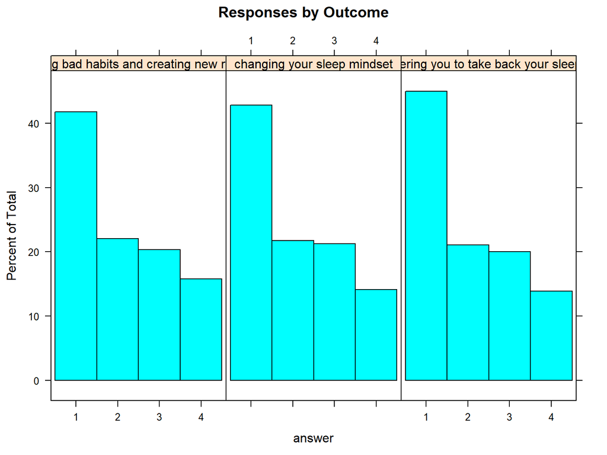

```r
experiment_data %>%
  histogram(~ answer | outcome,
            main = "Responses by Outcome",
            data = .)
```

'breaking bad habits and creating new routines' looks most promising with the lowest rate of 1s and the highest rate of 4s.

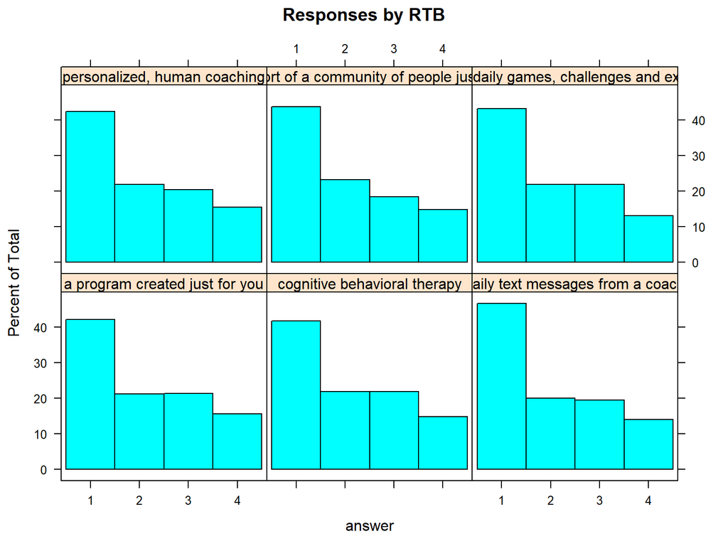

```r
experiment_data %>%
  histogram(~ answer | rtb,
            main = "Responses by RTB",
            data = .)
```

Although there are no standout winners for 'rtb', there are a few losers. 'daily text messages from a coach' shows a higher rate of 1's while 'personalized, human coaching' and 'the suppport of a community of people just like you' show more 2's and less 3's than average.

#### Social Proof

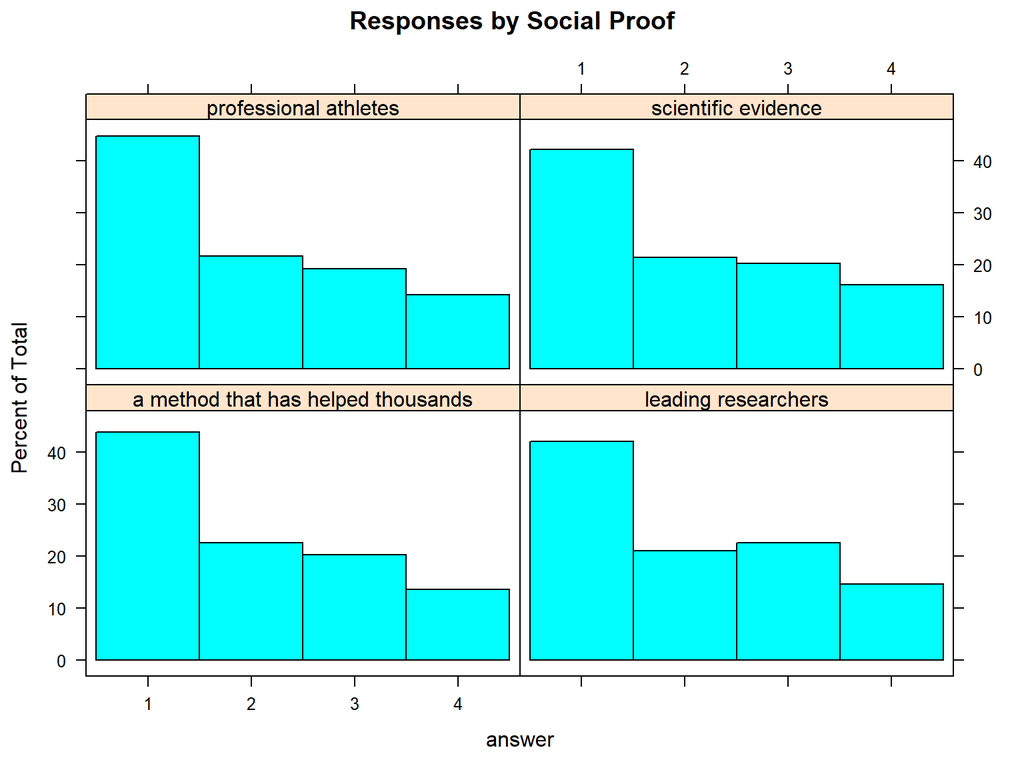

```r
experiment_data %>%
  histogram(~ answer | social_proof,
            main = "Responses by Social Proof",
            data = .)
```

#### Task Number

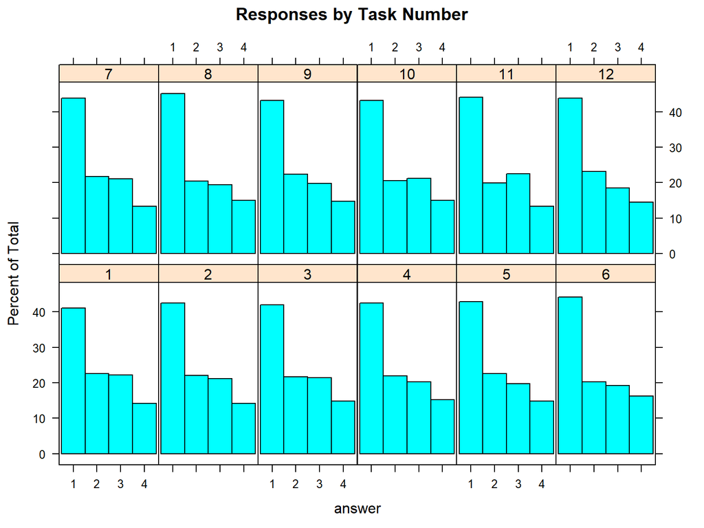

```r
experiment_data %>%
  histogram(~ answer | task,
            main = "Responses by Task Number",
            data = .,
            layout = c(6,2))
```

### Fitting a Model

The previous distributions gave us a feel for how the data is distributed and now we will consider each variable together in a linear model. Given that our dependent variable is ordinal, we will be using the 'ordinal' package which contains many helpful functions for ordinal regression. It is important to note that 'response_id' requires special treatment. In the model, this should will be considered a random effect because each rating in the data is not made by a unique person.

The 'clmm' function allows us to fit a cumulative link mixed model (analagous to a mixed ordinal regression model), which allows for each parameter type our model requires. These are:

##### Fixed

duration, price, offer, outcome, rtb, social_proof

##### Random

response_id

##### Dependent

answer

NOTE: This task is inferential rather than predictive, so data will not need to undergo typical predictive treatment such as splitting and training.

```r
ORModel <- experiment_data %>%
  sample_n(1000) %>%
  clmm(answer ~ duration  + price + offer + outcome + rtb + social_proof + (1|response_id),
       data = .,
      Hess = TRUE)

summary(ORModel)
```

```
Cumulative Link Mixed Model fitted with the Laplace approximation

formula: answer ~ duration + price + offer + outcome + rtb + social_proof +      (1 | response_id)
data:    .

 link  threshold nobs logLik   AIC     niter       max.grad cond.H
 logit flexible  1000 -1154.63 2353.27 2375(18724) 1.22e-03 4.1e+02

Random effects:
 Groups      Name        Variance Std.Dev.
 response_id (Intercept) 14.13    3.759
Number of groups:  response_id 623

Coefficients:
                                                      Estimate Std. Error z value Pr(>|z|)
duration3 months                                        0.1566     0.2718   0.576    0.565
duration6 months                                        0.0619     0.2636   0.235    0.814
price$30/month                                         -1.2447     0.2805  -4.437 9.12e-06 ***
price$40/month                                         -1.5572     0.2778  -5.605 2.08e-08 ***
offerhelp you lead a better life                        0.3360     0.3347   1.004    0.315
offerhelp you sleep without more pills                  0.1638     0.3379   0.485    0.628
offerimprove your health for the long-run               0.1701     0.3525   0.482    0.629
offerimprove your sleep sustainably                     0.1091     0.3430   0.318    0.750
outcomechanging your sleep mindset                     -0.2489     0.2667  -0.933    0.351
outcomeempowering you to take back your sleep habits   -0.4345     0.2682  -1.620    0.105
rtbcognitive behavioral therapy                         0.4757     0.3727   1.276    0.202
rtbdaily text messages from a coach                     0.1750     0.3709   0.472    0.637
rtbpersonalized, human coaching                         0.1902     0.3680   0.517    0.605
rtbthe support of a community of people just like you   0.2358     0.3908   0.603    0.546
rtbunique daily games, challenges and exercises         0.1577     0.3848   0.410    0.682
social_proofleading researchers                         0.1860     0.3034   0.613    0.540
social_proofprofessional athletes                       0.1501     0.2950   0.509    0.611
social_proofscientific evidence                         0.2548     0.3138   0.812    0.417
---
Signif. codes:  0 '***' 0.001 '**' 0.01 '*' 0.05 '.' 0.1 ' ' 1

Threshold coefficients:
    Estimate Std. Error z value
1|2  -1.2802     0.4982  -2.570
2|3   1.0762     0.4903   2.195
3|4   4.1261     0.5560   7.421
```